# u12

## Shared Qs (u12)

#### Question

1. A circle with radius $r=9$ centimeters is cut into 3 congruent sectors. A length of red string is pulled around the circle, and the string is exactly long enough to span the arc of 2 adjacent sectors, as shown in the diagram below.

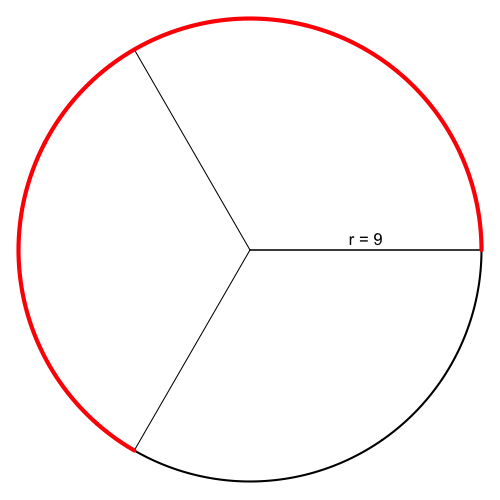

   How long, in centimeters, is the red string? Please answer as a decimal approximation accurate within $\pm 0.01$ centimeters.

#### Solution

#### Question

2. A circle with radius $r=4$ centimeters is cut into 7 congruent sectors. A length of red string is pulled around the circle, and the string is exactly long enough to span the arc of 6 adjacent sectors, as shown in the diagram below.

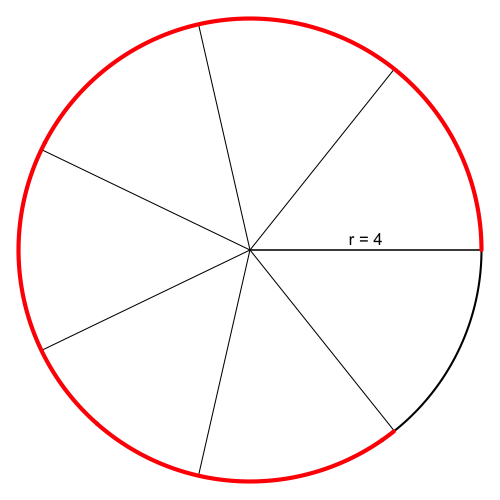

   How long, in centimeters, is the red string? Please answer as a decimal approximation accurate within $\pm 0.01$ centimeters.

#### Solution

#### Question

3. A circle with radius $r=8$ centimeters is cut into 9 congruent sectors. A length of red string is pulled around the circle, and the string is exactly long enough to span the arc of 7 adjacent sectors, as shown in the diagram below.

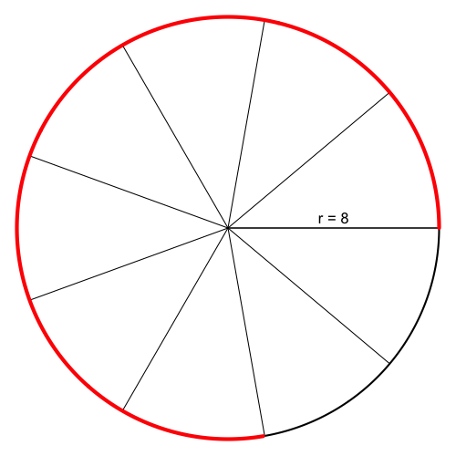

   How long, in centimeters, is the red string? Please answer as a decimal approximation accurate within $\pm 0.01$ centimeters.

#### Solution

#### Question

4. A circle with radius $r=5$ centimeters is cut into 9 congruent sectors. A length of red string is pulled around the circle, and the string is exactly long enough to span the arc of 8 adjacent sectors, as shown in the diagram below.

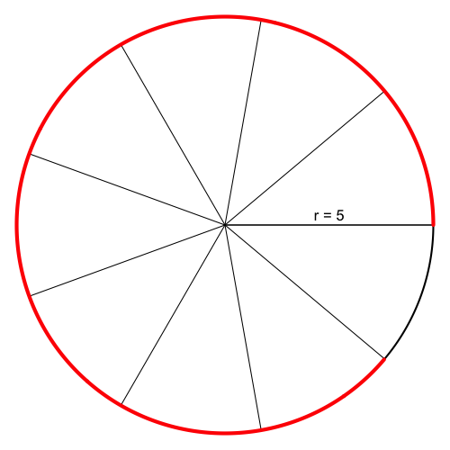

   How long, in centimeters, is the red string? Please answer as a decimal approximation accurate within $\pm 0.01$ centimeters.

#### Solution

#### Question

5. A circle with radius $r=3$ centimeters is cut into 7 congruent sectors. A length of red string is pulled around the circle, and the string is exactly long enough to span the arc of 5 adjacent sectors, as shown in the diagram below.

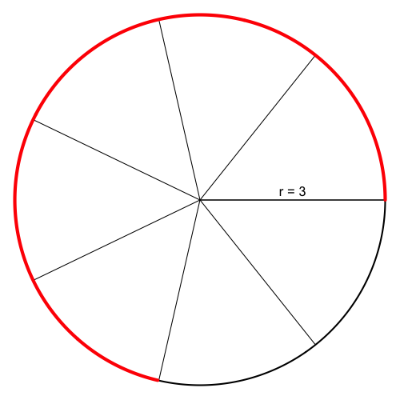

   How long, in centimeters, is the red string? Please answer as a decimal approximation accurate within $\pm 0.01$ centimeters.

#### Solution

#### Question

6. A length of red string is pulled around the circle with radius $r=8$. The red string [subtends](https://en.wikipedia.org/wiki/Subtended_angle) a [central angle](https://en.wikipedia.org/wiki/Central_angle) with a degree measure of 308°, as shown in the diagram below.

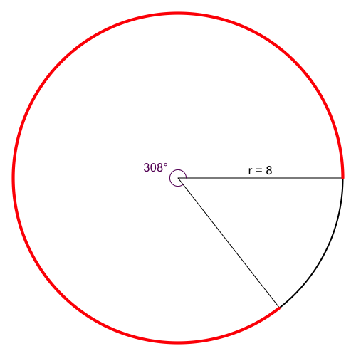

   How long, in centimeters, is the red string? Please answer as a decimal approximation accurate within $\pm 0.01$ centimeters.

#### Solution

#### Question

7. A length of red string is pulled around the circle with radius $r=3$. The red string [subtends](https://en.wikipedia.org/wiki/Subtended_angle) a [central angle](https://en.wikipedia.org/wiki/Central_angle) with a degree measure of 124°, as shown in the diagram below.

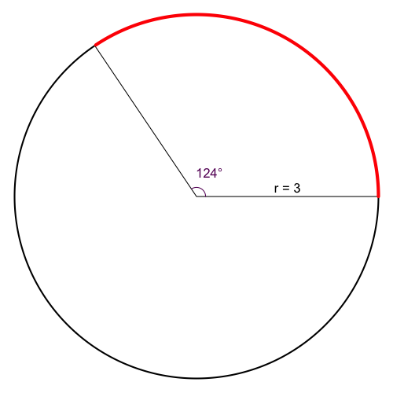

   How long, in centimeters, is the red string? Please answer as a decimal approximation accurate within $\pm 0.01$ centimeters.

#### Solution

#### Question

8. A length of red string is pulled around the circle with radius $r=7$. The red string [subtends](https://en.wikipedia.org/wiki/Subtended_angle) a [central angle](https://en.wikipedia.org/wiki/Central_angle) with a degree measure of 82°, as shown in the diagram below.

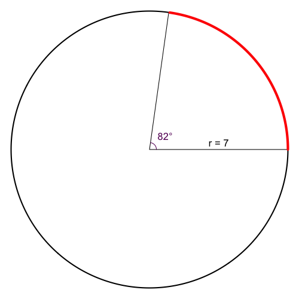

   How long, in centimeters, is the red string? Please answer as a decimal approximation accurate within $\pm 0.01$ centimeters.

#### Solution

#### Question

9. A length of red string is pulled around the circle with radius $r=3$. The red string [subtends](https://en.wikipedia.org/wiki/Subtended_angle) a [central angle](https://en.wikipedia.org/wiki/Central_angle) with a degree measure of 262°, as shown in the diagram below.

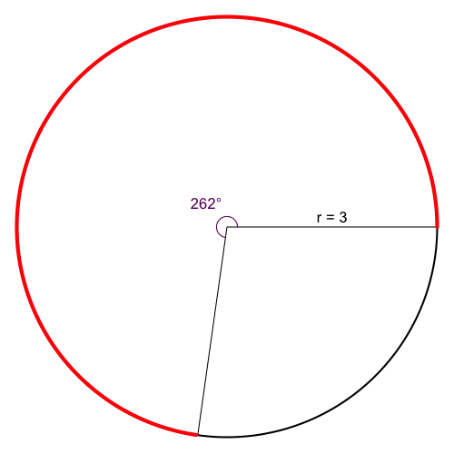

   How long, in centimeters, is the red string? Please answer as a decimal approximation accurate within $\pm 0.01$ centimeters.

#### Solution

#### Question

10. A length of red string is pulled around the circle with radius $r=4$. The red string [subtends](https://en.wikipedia.org/wiki/Subtended_angle) a [central angle](https://en.wikipedia.org/wiki/Central_angle) with a degree measure of 134°, as shown in the diagram below.

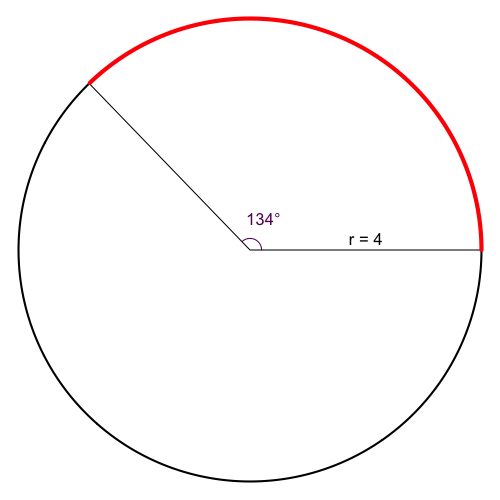

    How long, in centimeters, is the red string? Please answer as a decimal approximation accurate within $\pm 0.01$ centimeters.

#### Solution

#### Question

11. A length of red string is pulled around the circle with radius $r=6$. The red string [subtends](https://en.wikipedia.org/wiki/Subtended_angle) a [central angle](https://en.wikipedia.org/wiki/Central_angle) with a degree measure of $\psi$°, and the red string also subtends an **[inscribed angle](https://en.wikipedia.org/wiki/Inscribed_angle)** with degree measure of 98°.

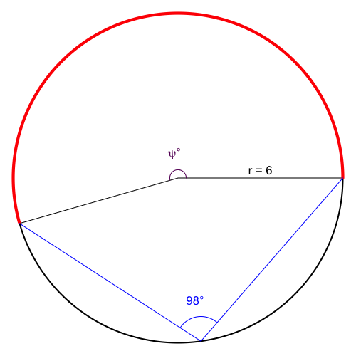

    How long, in centimeters, is the red string? Please answer as a decimal approximation accurate within $\pm 0.01$ centimeters.

#### Solution

#### Question

12. A length of red string is pulled around the circle with radius $r=3$. The red string [subtends](https://en.wikipedia.org/wiki/Subtended_angle) a [central angle](https://en.wikipedia.org/wiki/Central_angle) with a degree measure of $\psi$°, and the red string also subtends an **[inscribed angle](https://en.wikipedia.org/wiki/Inscribed_angle)** with degree measure of 54°.

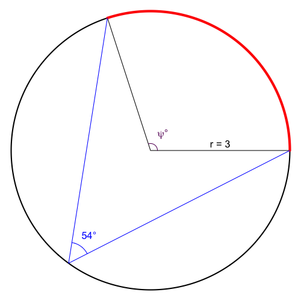

    How long, in centimeters, is the red string? Please answer as a decimal approximation accurate within $\pm 0.01$ centimeters.

#### Solution

#### Question

13. A length of red string is pulled around the circle with radius $r=8$. The red string [subtends](https://en.wikipedia.org/wiki/Subtended_angle) a [central angle](https://en.wikipedia.org/wiki/Central_angle) with a degree measure of $\psi$°, and the red string also subtends an **[inscribed angle](https://en.wikipedia.org/wiki/Inscribed_angle)** with degree measure of 93°.

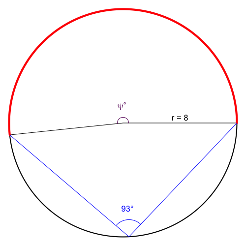

    How long, in centimeters, is the red string? Please answer as a decimal approximation accurate within $\pm 0.01$ centimeters.

#### Solution

#### Question

14. A length of red string is pulled around the circle with radius $r=4$. The red string [subtends](https://en.wikipedia.org/wiki/Subtended_angle) a [central angle](https://en.wikipedia.org/wiki/Central_angle) with a degree measure of $\psi$°, and the red string also subtends an **[inscribed angle](https://en.wikipedia.org/wiki/Inscribed_angle)** with degree measure of 57°.

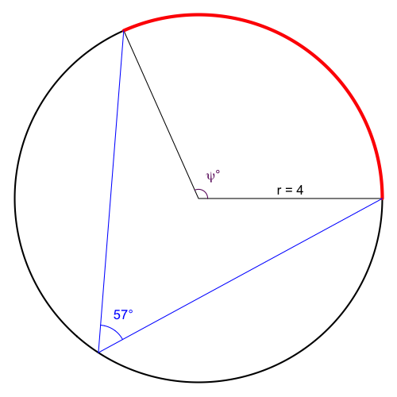

    How long, in centimeters, is the red string? Please answer as a decimal approximation accurate within $\pm 0.01$ centimeters.

#### Solution

#### Question

15. A length of red string is pulled around the circle with radius $r=9$. The red string [subtends](https://en.wikipedia.org/wiki/Subtended_angle) a [central angle](https://en.wikipedia.org/wiki/Central_angle) with a degree measure of $\psi$°, and the red string also subtends an **[inscribed angle](https://en.wikipedia.org/wiki/Inscribed_angle)** with degree measure of 39°.

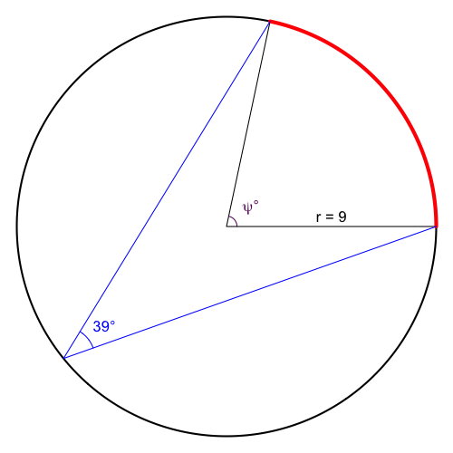

    How long, in centimeters, is the red string? Please answer as a decimal approximation accurate within $\pm 0.01$ centimeters.

#### Solution

#### Question

16. Two concentric circles have radii $r_1=1$ meters and $r_2=3.79$ meters. A central angle subtends similar arcs on both circles: a blue arc on the smaller circle and a red arc on the larger circle. The blue arc length is 1.12 meters, as shown in the diagram below.

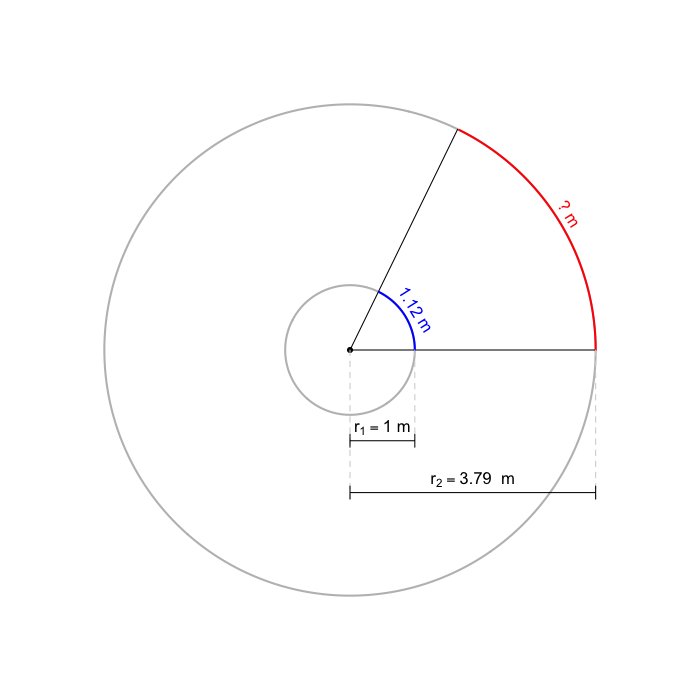

    What is the length, in meters, of the red arc? *The tolerance is set to $\pm0.01$ meters.*

#### Solution

#### Question

17. Two concentric circles have radii $r_1=1$ meters and $r_2=3.03$ meters. A central angle subtends similar arcs on both circles: a blue arc on the smaller circle and a red arc on the larger circle. The blue arc length is 1.54 meters, as shown in the diagram below.

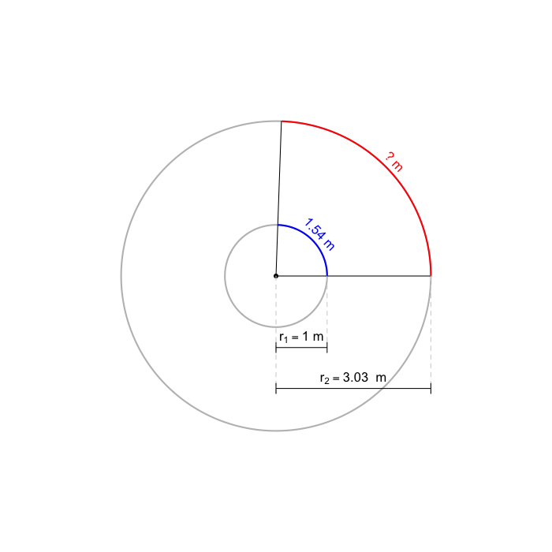

    What is the length, in meters, of the red arc? *The tolerance is set to $\pm0.01$ meters.*

#### Solution

#### Question

18. Two concentric circles have radii $r_1=1$ meters and $r_2=4.1$ meters. A central angle subtends similar arcs on both circles: a blue arc on the smaller circle and a red arc on the larger circle. The blue arc length is 2.29 meters, as shown in the diagram below.

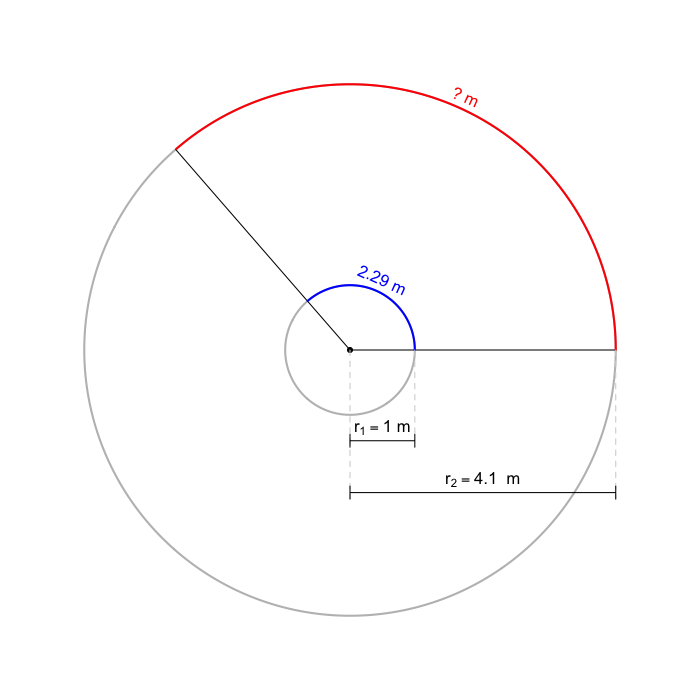

    What is the length, in meters, of the red arc? *The tolerance is set to $\pm0.01$ meters.*

#### Solution

#### Question

19. Two concentric circles have radii $r_1=1$ meters and $r_2=3.72$ meters. A central angle subtends similar arcs on both circles: a blue arc on the smaller circle and a red arc on the larger circle. The blue arc length is 2.88 meters, as shown in the diagram below.

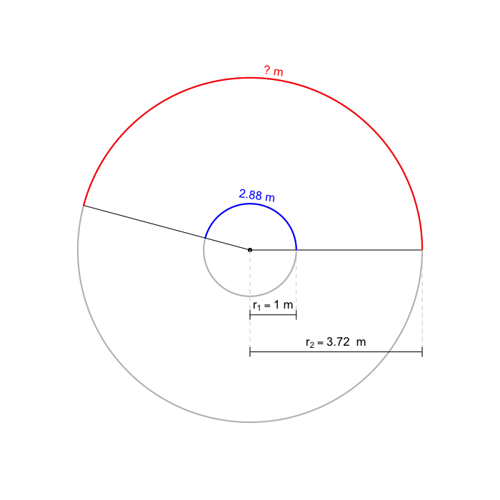

    What is the length, in meters, of the red arc? *The tolerance is set to $\pm0.01$ meters.*

#### Solution

#### Question

20. Two concentric circles have radii $r_1=1$ meters and $r_2=3.66$ meters. A central angle subtends similar arcs on both circles: a blue arc on the smaller circle and a red arc on the larger circle. The blue arc length is 3.77 meters, as shown in the diagram below.

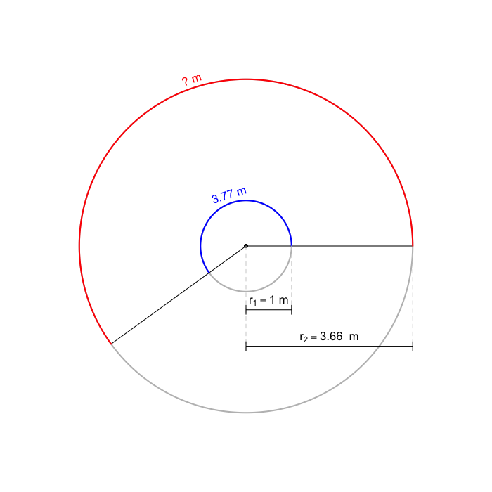

    What is the length, in meters, of the red arc? *The tolerance is set to $\pm0.01$ meters.*

#### Solution

#### Question

21. Two concentric circles have radii $r_1=1$ meters and $r_2=3.11$ meters. A central angle subtends similar arcs on both circles: a blue arc on the smaller circle and a red arc on the larger circle. The red arc length is 8.83 meters, as shown in the diagram below.

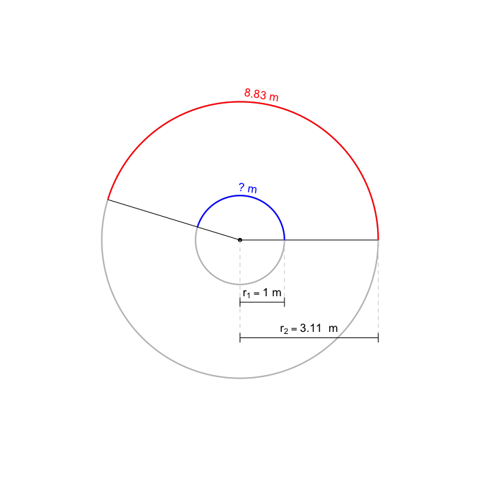

    What is the length, in meters, of the blue arc? *The tolerance is set to $\pm0.01$ meters.*

#### Solution

#### Question

22. Two concentric circles have radii $r_1=1$ meters and $r_2=3.47$ meters. A central angle subtends similar arcs on both circles: a blue arc on the smaller circle and a red arc on the larger circle. The red arc length is 14.64 meters, as shown in the diagram below.

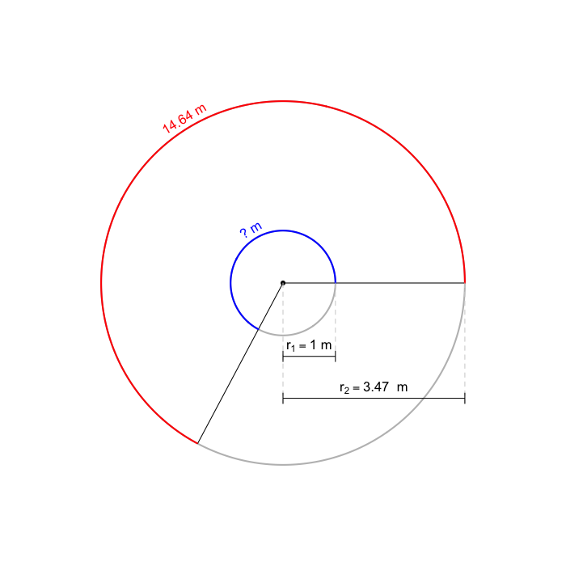

    What is the length, in meters, of the blue arc? *The tolerance is set to $\pm0.01$ meters.*

#### Solution

#### Question

23. Two concentric circles have radii $r_1=1$ meters and $r_2=3.99$ meters. A central angle subtends similar arcs on both circles: a blue arc on the smaller circle and a red arc on the larger circle. The red arc length is 5.79 meters, as shown in the diagram below.

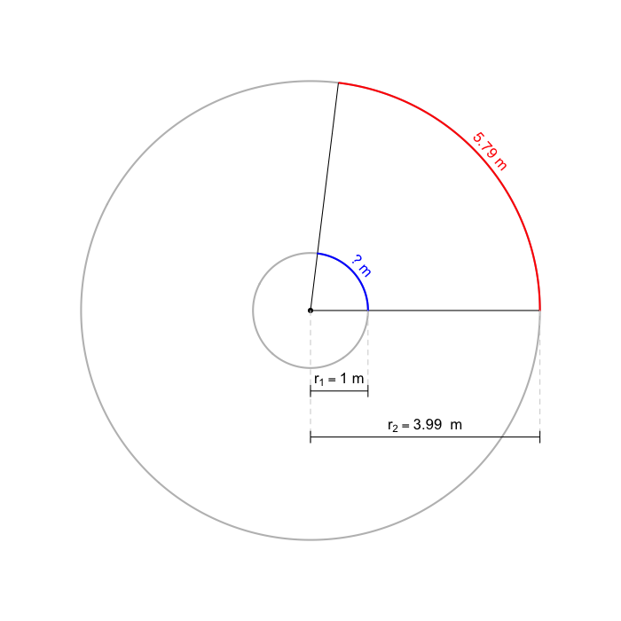

    What is the length, in meters, of the blue arc? *The tolerance is set to $\pm0.01$ meters.*

#### Solution

#### Question

24. Two concentric circles have radii $r_1=1$ meters and $r_2=4.37$ meters. A central angle subtends similar arcs on both circles: a blue arc on the smaller circle and a red arc on the larger circle. The red arc length is 6.56 meters, as shown in the diagram below.

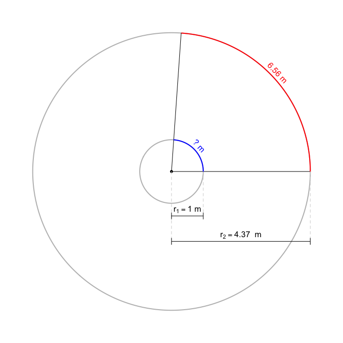

    What is the length, in meters, of the blue arc? *The tolerance is set to $\pm0.01$ meters.*

#### Solution

#### Question

25. Two concentric circles have radii $r_1=1$ meters and $r_2=3.69$ meters. A central angle subtends similar arcs on both circles: a blue arc on the smaller circle and a red arc on the larger circle. The red arc length is 4.39 meters, as shown in the diagram below.

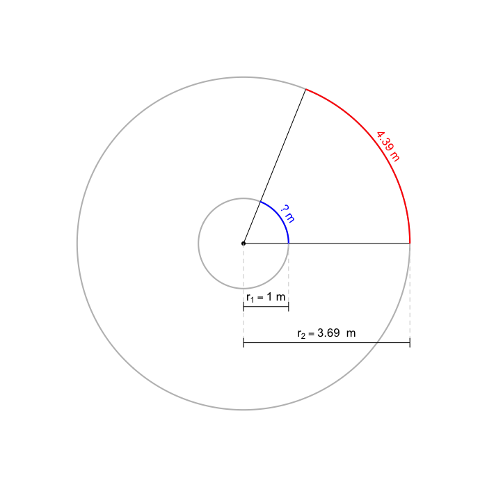

    What is the length, in meters, of the blue arc? *The tolerance is set to $\pm0.01$ meters.*

#### Solution

#### Question

26. The radian measure of an angle is the length of the arc on the [unit circle](https://en.wikipedia.org/wiki/Unit_circle) subtended by the angle. In mathematics, radians are the default way to measure an angle.

    Consider a circle with a radius of length $r=1$ meter. A [central angle](https://en.wikipedia.org/wiki/Central_angle), in [standard position](https://libraryguides.centennialcollege.ca/c.php?g=716824&p=5112868), subtends an arc of length $2.83$ meters.

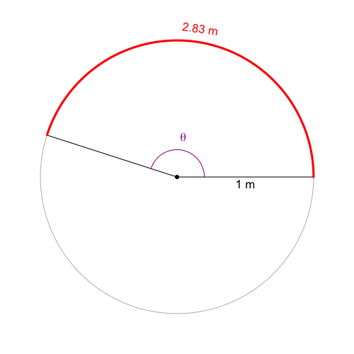

    The central angle, measured in degrees, is approximately equal to 162°. However, from the radius and the arc length, you should be able to calculate the angle in radians exactly.

    **Find $\theta$ in radians**.

#### Solution

#### Question

27. The radian measure of an angle is the length of the arc on the [unit circle](https://en.wikipedia.org/wiki/Unit_circle) subtended by the angle. In mathematics, radians are the default way to measure an angle.

    Consider a circle with a radius of length $r=1$ meter. A [central angle](https://en.wikipedia.org/wiki/Central_angle), in [standard position](https://libraryguides.centennialcollege.ca/c.php?g=716824&p=5112868), subtends an arc of length $1.6$ meters.

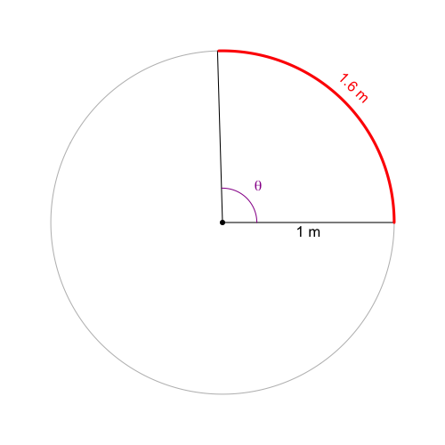

    The central angle, measured in degrees, is approximately equal to 92°. However, from the radius and the arc length, you should be able to calculate the angle in radians exactly.

    **Find $\theta$ in radians**.

#### Solution

#### Question

28. The radian measure of an angle is the length of the arc on the [unit circle](https://en.wikipedia.org/wiki/Unit_circle) subtended by the angle. In mathematics, radians are the default way to measure an angle.

    Consider a circle with a radius of length $r=1$ meter. A [central angle](https://en.wikipedia.org/wiki/Central_angle), in [standard position](https://libraryguides.centennialcollege.ca/c.php?g=716824&p=5112868), subtends an arc of length $2.29$ meters.

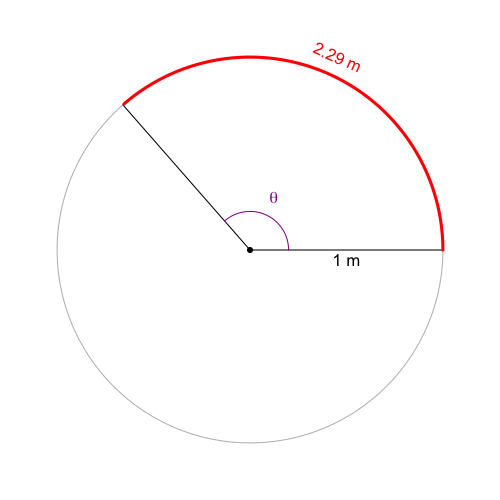

    The central angle, measured in degrees, is approximately equal to 131°. However, from the radius and the arc length, you should be able to calculate the angle in radians exactly.

    **Find $\theta$ in radians**.

#### Solution

#### Question

29. The radian measure of an angle is the length of the arc on the [unit circle](https://en.wikipedia.org/wiki/Unit_circle) subtended by the angle. In mathematics, radians are the default way to measure an angle.

    Consider a circle with a radius of length $r=1$ meter. A [central angle](https://en.wikipedia.org/wiki/Central_angle), in [standard position](https://libraryguides.centennialcollege.ca/c.php?g=716824&p=5112868), subtends an arc of length $3.19$ meters.

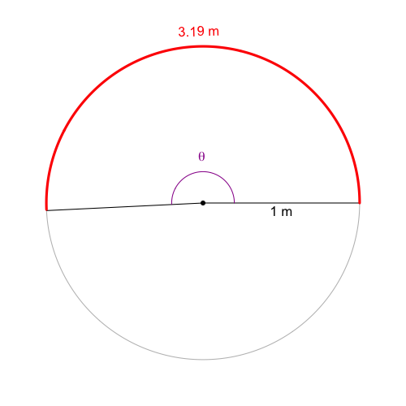

    The central angle, measured in degrees, is approximately equal to 183°. However, from the radius and the arc length, you should be able to calculate the angle in radians exactly.

    **Find $\theta$ in radians**.

#### Solution

#### Question

30. The radian measure of an angle is the length of the arc on the [unit circle](https://en.wikipedia.org/wiki/Unit_circle) subtended by the angle. In mathematics, radians are the default way to measure an angle.

    Consider a circle with a radius of length $r=1$ meter. A [central angle](https://en.wikipedia.org/wiki/Central_angle), in [standard position](https://libraryguides.centennialcollege.ca/c.php?g=716824&p=5112868), subtends an arc of length $1.05$ meters.

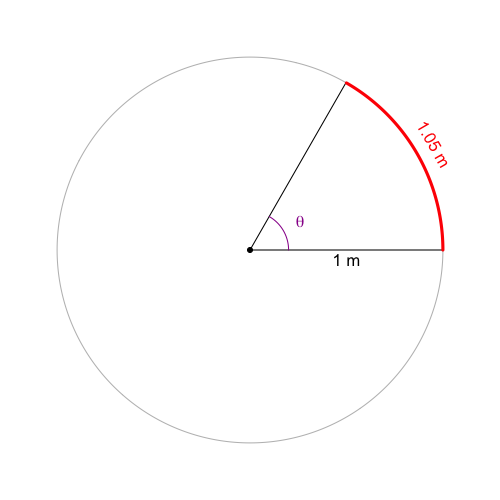

    The central angle, measured in degrees, is approximately equal to 60°. However, from the radius and the arc length, you should be able to calculate the angle in radians exactly.

    **Find $\theta$ in radians**.